# Changing Norms and Partisan Polarization

How elites advance mass polarization

Damon C. Roberts, University of Colorado Boulder

### Question

Do behavioral manifestations of political polarization among elites influence polarization among the public?

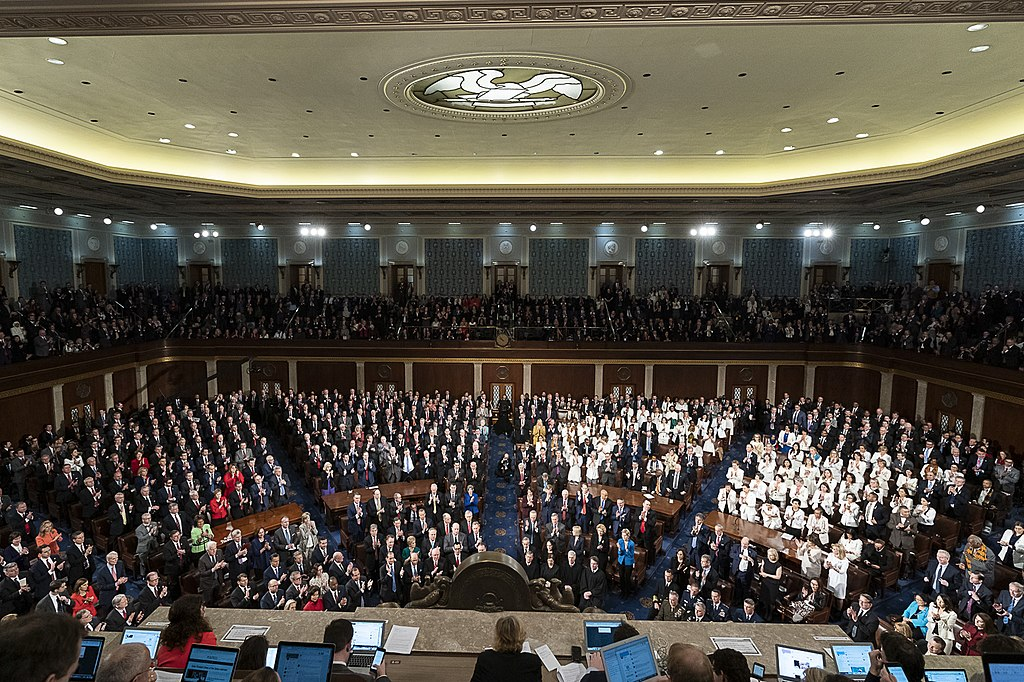

2019 State of the Union, Credit: Ohio State News

### Political polarization among the public versus elites

- The public are polarized on policy (Abramowitz and Saunders 2006) and are affectively polarized (Iyengar, Sood, and Lelkes 2012).
- Elites are not just polarized on the issues, but they are also affectively polarized (Enders 2021).

### Where does this come from?

- Some argue that polarization is a symptom of ideological and partisan sorting (e.g., Fiorina and Abrams 2008).
- Others take a more social identity theory approach:
  - partisanship is greater than just issue attitudes, but it reflects a social identity (Campbell et al. 1969)
  - polarization is a reflection of people expressing their partisan identification (Huddy, Mason, and Aarøe 2015)
  - it is increasing as a result of clearer group distinction and differentiation (Mason 2018)

### What are the implications?

- There are many, but some examples are:
  - the public increasingly distrust and loathe out-partisans (Iyengar, Sood, and Lelkes 2012)
  - voters are more likely to support politically extreme candidates in primaries (Utych 2020)
  - express co-partisan preferences in potential dating partners (Nicholson et al. 2016; Huber and Malhotra 2017)
  - express preferences to live in neighborhoods that appear characteristically (Hetherington and Weiler 2018) co-partisan (Liu, Andris, and Desmarais 2019)
  - have strong affective reactions to the prospect of having conversations with out-partisans (Carlson and Settle 2022)

### How does this differentiation occur?

- Many blame elites
  - the media act as gatekeepers who give a platform to ideologically extreme views (Padgett, Dunaway, and Darr 2019)
  - politicians are in ideological conflict and that this conflict is extended to the public (Layman and Carsey 2002)

### What do norms have to play in this?

- As elites appear to be polarized, we shouldn’t expect that they just express this polarization through speeches, media appearances, statements, etc.
  - elites engage in behavior that might be interpreted as polarized.
  - e.g., the tendency for Republicans to mingle with Republicans and Democrats to mingle with Democrats on the house floor (Dietrich 2021)
- Beyond these traditional ways that elites may teach the public about norms of being a good partisan - which the public express preferences to learn and follow(Pickup, Kimbrough, and Rooij 2020) - the public may also learn from behavioral manifestations of it.
  - They want to do it because identifiers with a social group often have motivations to feel like they are part of the group.
  - They have that information there and it might be more accessible relative to things like the SOTU, campaigns, floor votes, etc.

### So what might we expect if this is the case?

When the public view media that highlight and evaluate this differencing behavior among elites, they will:

- **$H_1$**: be able to detect such differencing behavior
- **$H_2$**: be okay with their co-partisan representatives to engage in such behavior
- **$H_3$**: they will see it as appropriate behavior for them and other co-partisans to engage in
- **$H_4$**: will view these same behaviors by out-partisans as inappropriate
- **$H_5$**: and will hold negative atttitudes toward out-partisans who do this

## Proposed Experiment

- Separated in pre-analysis plan as three separate studies, but the plan is to run one experiment.
- $2 \times 2$ factorial design
  - after informed consent, demographic and political attitudes questionaire, subjects are assigned into 4 conditions

Table 1: Proposed design

|  | Congruent | Incongruent |
| --- | --- | --- |
| Difference | 1 | 2 |
| Bi-partisanship | 3 | 4 |

> Congress introduced a new bill today. The bill **[disliked by Republicans/disliked by Democrats/disliked by many/disliked by many]** is meant to address funding concerns for high-use interstate highways. In reference to the bill, **[Republican Leadership/Democratic Leadership/a Republican-lead bipartisan coalition/a Democrat-lead bipartisan coalition]** expressed their feelings indicating that they felt this bill was not important. During the floor vote **[Republicans spoke at length about the Democrats’ desire to slow Congress down with “pointless bills”/Democrats spoke at length about the Republicans’ desire to slow Congress down with “pointless bills”/prominent Republicans representing a bipartisan coalition spoke at length about their belief that there are more pressing concerns/prominent Democrats representing a bipartisan coalition spoke at length about their belief that there are more pressing concerns]**. Afterwards on the floor, **[Republicans were huddled talking about how to make sure it doesn’t come back up for a vote next session/Democrats were huddled talking about how to make sure it doesn’t come back up for a vote next session/Republicans joined Democratic colleagues in a huddle talking about strategies to make sure it doesn’t come back up for a vote next session/Democrats joined Republican colleagues in a huddle talking about strategies to make sure it doesn’t come back up for a vote next session]**. That afternoon, when speaking to the press, **[Republican leaders talked about how Democrats don’t care about the well-being of the country and are becoming more out-of-step with Americans/Democratic leaders talked about how Republicans don’t care about the well-being of the country and are becoming more out-of-step with Americans/Republican leaders talked about how great it is to make sure everything is just right to make the bill work for Americans/Democratic leaders talked about how great it is to make sure everything is just right to make the bill work for Americans]**.
1. Which statement do you think characterizes the behavior of the politicians covered in the brief report the best?
- Unified
- Normal
- Divided
2. Do you think the party leaders should be:
- Rewarded by others in the party for how they handled the situation
- Others in the party shouldn’t do anything as a result of how they handled the situation
- Punished by others in the party for how they handled the situation
3. On a scale of 0-100, where 0 represents “Cold” and 100 represents Very Warm, how do you feel about:
- Republicans
- Democrats

# Power analysis

- Use Blair et al. (2019) MIDA approach by creating a number of simulated studies and comparing across them when varying a feature. In this case, the sample size.
- Estimates: range from -0.9 to 0.9
- Sample: 250, 1000, 1500

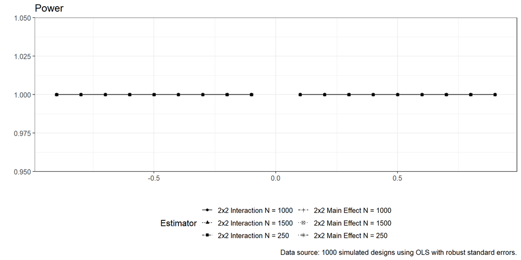

Figure 1: 1000 simulated designs using OLS with robust standard errors

### I’d love your feedback!

Contact: damon.roberts-1[at]colorado.edu

Materials: github.com/damoncroberts/elite_norms_mass_polarization

### References

Abramowitz, Alan I., and Kyle L. Saunders. 2006. “Exploring the bases of Partisanship in the American electorate: Social identity vs. ideology.” *Political Research Quarterly* 59 (2): 175–87. https://doi.org/10.1177/106591290605900201.

Blair, Graeme, Jasper Cooper, Alexander Coppock, and Macartan Humphreys. 2019. “Declaring and Diagnosing Research Designs.” *American Political Science Review*. https://doi.org/10.1017/S000305541900094.

Campbell, Angus, Phillip E. Converse, Warren E. Miller, and Donald E. Stokes. 1969. *The American Voter*. Chicago, IL: John Wiley; Sons, Inc.

Carlson, Taylor N., and Jaime E. Settle. 2022. *What Goes Without Saying: Navigating Political Discussion in America*. New York: Cambridge University Press.

Dietrich, Bryce J. 2021. “Using Motion Detection to Measure Social Polarization in the u.s. House of Representatives.” *Political Analysis* 29 (2): 250–59. https://doi.org/10.1017/pan.2020.25.

Enders, Adam M. 2021. “Issues Versus Affect: How Do Elite and Mass Polarization Compare?” *The Journal of Politics* 83 (4): 1872–77.

Fiorina, Morris P., and Samuel J. Abrams. 2008. “Political Polarization in the American Public.” *Annual Review of Political Science* 11 (1): 563–88. https://doi.org/10.1146/annurev.polisci.11.053106.153836.

Hetherington, Marc J., and Jonathan Weiler. 2018. *Prius or Pickup? How the Answers to Four Simple Questions Explain America’s Great Divide*. New York: Houghton Mifflin Harcourt.

Huber, Gregory A., and Neil Malhotra. 2017. “Political homophily in social relationships: Evidence from online dating behavior.” *Journal of Politics* 79 (1): 269–83. https://doi.org/10.1086/687533.

Huddy, Leonie, Lilliana Mason, and Aarøe. 2015. “Expressive Partisanship: Campaign Involvement, Political Emotion, and Political Identity.” *American Political Science Review* 109 (1).

Iyengar, Shanto, Gaurav Sood, and Yphtach Lelkes. 2012. “Affect, not ideology: A social identity perspective on polarization.” *Public Opinion Quarterly* 76 (3): 405–31. https://doi.org/10.1093/poq/nfs038.

Layman, Geoffrey C., and Thomas M. Carsey. 2002. “Party Polarization and "Conflict Extension" in the American Electorate.” *American Journal of Political Science* 46 (4): 786–802.

Liu, Xi, Clio Andris, and Bruce A. Desmarais. 2019. “Migration and political polarization in the U.S.: An analysis of the county-level migration network.” *PLoS ONE* 14 (11): 1–16. https://doi.org/10.1371/journal.pone.0225405.

Mason, Lilliana. 2018. *Uncivil Agreeement*. Chicago, IL: University of Chicago Press.

Nicholson, Stephen P., Chelsea M. Coe, Jason Emory, and Anna V. Song. 2016. “The Politics of Beauty: The Effects of Partisan Bias on Physical Attractiveness.” *Political Behavior* 38 (4): 883–98. https://doi.org/10.1007/s11109-016-9339-7.

Padgett, Jeremy, Johanna L. Dunaway, and Joshua P. Darr. 2019. “As seen on TV? How gatekeeping makes the U.S. House seem more extreme.” *Journal of Communication* 69 (6): 696–719. https://doi.org/10.1093/joc/jqz039.

Pickup, Mark, Erik O. Kimbrough, and Eline A. de Rooij. 2020. “Expressive Politics as (Costly) Norm Following.” *Political Behavior*. https://doi.org/10.1007/s11109-020-09667-6.

Utych, Stephen M. 2020. “A Voter-Centric Explanation of the Success of Ideological Candidates for the US House.” *Electoral Studies* 65: 102137.